# Introduction

> Provide an introduction to your analysis. (minimum 5 sentences) Your director has tasked you with analyzing the impact of photo content. In short, your company has long operated under the general idea that photos are the most engaging form of social media content, and that they should advise their clients to post as many of these as they can.

The objective of this project was to analyze a dataset of Facebook posts and their engagement metrics, through principal component analysis, KMeans clustering, and finally a binary classification task.

I found that 4 principal components represent the underlying data:

- Highly Engaging
- Positive and Surprising
- Outrageous
- Emotionally Polarizing

I also found that the PCA-based data can be clustered well into 5 segments:

- Not Engaging 🥱
- Angry Outliers 😡
- Positive and Surprising 🤩
- Super Engaging 😁
- Sad Outliers 😭

I also analyzed the status types of each segment and discovered that photos tend to have fewer highly engaging posts compared to video, and have several specific outliers that elicit many angry and sad reactions.

Lastly, I compared several logistic regression models and found that the model using the "Retained Principal Component" features was best because it had good test performance and, notably, the smallest train-test gap of all the models.

# Imports and Loading Data

```python
########################################
# importing packages
########################################
import numpy             as np                   # mathematical essentials
import pandas            as pd                   # data science essentials
import matplotlib.pyplot as plt                  # fundamental data visualization
import seaborn           as sns                  # enhanced visualization
from sklearn.preprocessing import StandardScaler # standard scaler
from sklearn.decomposition import PCA            # pca
from scipy.cluster.hierarchy import dendrogram, linkage # dendrograms
from sklearn.cluster         import KMeans              # k-means clustering
from sklearn.model_selection import train_test_split        # train-test split
from sklearn.metrics import confusion_matrix, roc_auc_score # results analysis
import sklearn.linear_model                                 # classification modeling
```

```python
# loading data
df = pd.read_excel(io = './facebook_live_data.xlsx')
```

# Exploring the dataset

```python
# Display the first five rows of the Dataframe
df.head()
```

|  | status_id | status_type | time_published | num_comments | num_shares | num_likes | num_loves | num_wows | num_hahas | num_sads | num_angrys |
| --- | --- | --- | --- | --- | --- | --- | --- | --- | --- | --- | --- |
| 0 | 1 | photo | 2023-07-04 22:45:00 | 0 | 0 | 150 | 0 | 0 | 0 | 0 | 0 |
| 1 | 2 | photo | 2023-06-23 01:01:00 | 2 | 3 | 202 | 7 | 1 | 0 | 0 | 0 |
| 2 | 3 | photo | 2023-06-21 02:23:00 | 4 | 0 | 200 | 8 | 1 | 0 | 0 | 0 |
| 3 | 4 | video | 2023-06-14 05:16:00 | 100 | 30 | 303 | 23 | 1 | 5 | 0 | 0 |
| 4 | 5 | video | 2023-06-08 08:28:00 | 173 | 47 | 132 | 16 | 1 | 0 | 1 | 0 |

```python
# Group data by 'status_type' and provide statistical summary for each group
df.groupby('status_type').describe()
```

| status_type | status_id count | status_id mean | status_id min | status_id 25% | status_id 50% | status_id 75% | status_id max | status_id std | time_published count | time_published mean | ... | num_sads max | num_sads std | num_angrys count | num_angrys mean | num_angrys min | num_angrys 25% | num_angrys 50% | num_angrys 75% | num_angrys max | num_angrys std |
| --- | --- | --- | --- | --- | --- | --- | --- | --- | --- | --- | --- | --- | --- | --- | --- | --- | --- | --- | --- | --- | --- |
| photo | 1443.0 | 1097.645877 | 1.0 | 621.5 | 1001.0 | 1676.50 | 2362.0 | 662.559883 | 1443 | 2021-09-24 21:32:30.187110400 | ... | 46.0 | 1.960677 | 1443.0 | 0.054054 | 0.0 | 0.0 | 0.0 | 0.0 | 31.0 | 1.006836 |
| text | 156.0 | 1257.153846 | 59.0 | 351.5 | 1194.5 | 2161.25 | 2349.0 | 847.434071 | 156 | 2022-04-29 23:30:15.384615424 | ... | 7.0 | 1.070856 | 156.0 | 0.012821 | 0.0 | 0.0 | 0.0 | 0.0 | 1.0 | 0.112862 |
| video | 763.0 | 1324.618611 | 4.0 | 561.5 | 1457.0 | 1807.00 | 2361.0 | 655.227492 | 763 | 2022-08-02 13:04:48.283092992 | ... | 37.0 | 1.719899 | 763.0 | 0.275229 | 0.0 | 0.0 | 0.0 | 0.0 | 8.0 | 0.760061 |

3 rows × 80 columns

```python
# Filter rows where status_type is 'photo', then describe numerical features with rounded decimals
df[df.status_type == 'photo'].describe(include = 'number').round(decimals = 2)
```

|  | status_id | num_comments | num_shares | num_likes | num_loves | num_wows | num_hahas | num_sads | num_angrys |
| --- | --- | --- | --- | --- | --- | --- | --- | --- | --- |
| count | 1443.00 | 1443.00 | 1443.00 | 1443.00 | 1443.00 | 1443.00 | 1443.00 | 1443.00 | 1443.00 |
| mean | 1097.65 | 22.03 | 3.04 | 175.45 | 1.39 | 0.68 | 0.12 | 0.17 | 0.05 |
| std | 662.56 | 273.53 | 35.33 | 445.47 | 4.90 | 2.50 | 1.13 | 1.96 | 1.01 |
| min | 1.00 | 0.00 | 0.00 | 0.00 | 0.00 | 0.00 | 0.00 | 0.00 | 0.00 |
| 25% | 621.50 | 0.00 | 0.00 | 15.00 | 0.00 | 0.00 | 0.00 | 0.00 | 0.00 |
| 50% | 1001.00 | 2.00 | 0.00 | 33.00 | 0.00 | 0.00 | 0.00 | 0.00 | 0.00 |
| 75% | 1676.50 | 10.00 | 1.00 | 114.50 | 1.00 | 0.00 | 0.00 | 0.00 | 0.00 |
| max | 2362.00 | 10194.00 | 1260.00 | 4315.00 | 120.00 | 38.00 | 28.00 | 46.00 | 31.00 |

```python
# Filter rows where status_type is 'video', then describe numerical features with rounded decimals
df[df.status_type == 'video'].describe(include = 'number').round(decimals = 2)
```

|  | status_id | num_comments | num_shares | num_likes | num_loves | num_wows | num_hahas | num_sads | num_angrys |
| --- | --- | --- | --- | --- | --- | --- | --- | --- | --- |
| count | 763.00 | 763.00 | 763.00 | 763.00 | 763.00 | 763.00 | 763.00 | 763.00 | 763.00 |
| mean | 1324.62 | 674.15 | 116.85 | 257.21 | 36.83 | 2.51 | 2.04 | 0.44 | 0.28 |
| std | 655.23 | 1356.88 | 190.54 | 435.61 | 65.64 | 14.79 | 6.88 | 1.72 | 0.76 |
| min | 4.00 | 0.00 | 0.00 | 0.00 | 0.00 | 0.00 | 0.00 | 0.00 | 0.00 |
| 25% | 561.50 | 0.00 | 0.00 | 29.00 | 0.00 | 0.00 | 0.00 | 0.00 | 0.00 |
| 50% | 1457.00 | 28.00 | 10.00 | 121.00 | 2.00 | 0.00 | 0.00 | 0.00 | 0.00 |
| 75% | 1807.00 | 776.50 | 181.50 | 239.50 | 49.00 | 1.00 | 2.00 | 0.00 | 0.00 |
| max | 2361.00 | 10960.00 | 1136.00 | 4094.00 | 421.00 | 278.00 | 102.00 | 37.00 | 8.00 |

```python
# Filter rows where status_type is 'text', then describe numerical features with rounded decimals
df[df.status_type == 'text'].describe(include = 'number').round(decimals = 2)
```

|  | status_id | num_comments | num_shares | num_likes | num_loves | num_wows | num_hahas | num_sads | num_angrys |
| --- | --- | --- | --- | --- | --- | --- | --- | --- | --- |
| count | 156.00 | 156.00 | 156.00 | 156.00 | 156.00 | 156.00 | 156.00 | 156.00 | 156.00 |
| mean | 1257.15 | 37.81 | 3.31 | 467.42 | 1.21 | 0.86 | 0.13 | 0.26 | 0.01 |
| std | 847.43 | 112.30 | 11.44 | 678.64 | 3.10 | 3.75 | 0.62 | 1.07 | 0.11 |
| min | 59.00 | 0.00 | 0.00 | 1.00 | 0.00 | 0.00 | 0.00 | 0.00 | 0.00 |
| 25% | 351.50 | 2.00 | 0.00 | 49.00 | 0.00 | 0.00 | 0.00 | 0.00 | 0.00 |
| 50% | 1194.50 | 7.00 | 0.00 | 109.00 | 0.00 | 0.00 | 0.00 | 0.00 | 0.00 |
| 75% | 2161.25 | 21.00 | 1.00 | 885.50 | 1.00 | 0.00 | 0.00 | 0.00 | 0.00 |
| max | 2349.00 | 1186.00 | 72.00 | 2799.00 | 23.00 | 33.00 | 5.00 | 7.00 | 1.00 |

> In terms of reactions (likes, loves, etc.), how do photos perform when compared to other forms of content? Are they leading in terms of total engagement? What about in engagement on specific reactions? (minimum 10 sentences)

First, one initial observation is that the data contains mostly photos (1443 examples), as well as a large number of videos (763) and a small number of text posts (156).

In terms of reactions (likes, loves, etc.), photos appear to perform the worst compared to videos and text content. The mean of reactions in each category for photos is lower than that for videos and text, with the exceptions of 'num_loves' and 'num_angrys,' where the mean for photos slightly outperforms that of text posts.

According to Julian Thompson (2013), total engagement on social media is defined as a comprehensive metric that combines both active and passive user interactions with content. Active interactions, such as likes, comments, and shares, amplify content visibility through networks of friends and can lead to viral spread. On the other hand, passive interactions include actions like post clicks, link clicks, and image views, which indicate content consumption without further dissemination. Within this framework of total engagement, the provided metrics show that photos are not the leading format. Instead, videos tend to attract a broader range of active reactions, indicating higher overall engagement, while text posts consistently garner the most likes.

In relation to specific reactions, photos seem to have a balanced but modest engagement profile. They do not lead in eliciting strong reactions compared to videos and text, but as mentioned above, they do have the edge over text in terms of 'loves' and 'angrys'. For likes, photos hold their ground with an average of 175.45, trailing behind text posts yet still demonstrating a decent level of engagement. Turning to 'wows', the mean for photos is 0.68, hinting that they can at times deliver content that is unexpectedly impactful, albeit less consistently than videos. Regarding 'hahas', photos generate a light-hearted response with a mean of 0.12, which, while lower than videos, signifies their ability to amuse. With a mean of 0.17 for 'sads', photos occasionally touch on more somber emotions, though less prominently than other content types.

References: Thompson, J. (2013, September 21). What Facebook engagement actually means Part I. Mosh Social Media. https://mosh.co.nz/what-facebook-engagement-actually-means-part-i/

# PCA Analysis

## PCA Prep

```python
# Helper functions

def scree_plot(pca_object, vertical_line_xloc=None):
    """
    Visualizes a scree plot from a pca object.

    If vertical_line_xloc is passed in, draws a vertical line at that x location.
    """
    # building a scree plot

    # setting plot size
    fig, ax = plt.subplots(figsize=(10, 8))
    features = range(pca_object.n_components_)


    # developing a scree plot
    plt.plot(features,
             pca_object.explained_variance_ratio_,
             linewidth = 2,
             marker = 'o',
             markersize = 10,
             markeredgecolor = 'black',
             markerfacecolor = 'grey')


    # setting more plot options
    plt.title('Scree Plot')
    plt.xlabel('PCA feature')
    plt.ylabel('Explained Variance')
    plt.xticks(features)

    if vertical_line_xloc:
        plt.axvline(vertical_line_xloc, linestyle='--', color='red')

    # displaying the plot
    plt.show()


########################################
# unsupervised_scaler
########################################
def scaler(df):
    """
    Standardizes a dataset (mean = 0, variance = 1). Returns a new DataFrame.
    Requires sklearn.preprocessing.StandardScaler()

    PARAMETERS
    ----------
    df     | DataFrame to be used for scaling
    """

    # INSTANTIATING a StandardScaler() object
    scaler = StandardScaler(copy = True)


    # FITTING the scaler with the data
    scaler.fit(df)


    # TRANSFORMING our data after fit
    x_scaled = scaler.transform(df)


    # converting scaled data into a DataFrame
    new_df = pd.DataFrame(x_scaled)


    # reattaching column names
    new_df.columns = list(df.columns)

    return new_df
```

```python
# Check information about non-missing values and data types for each column.
# The dataframe doesn't contain any null values, so we can move forward.
df.info(verbose = True)
```

```
<class 'pandas.core.frame.DataFrame'>
RangeIndex: 2362 entries, 0 to 2361
Data columns (total 11 columns):
 #   Column          Non-Null Count  Dtype
---  ------          --------------  -----
 0   status_id       2362 non-null   int64
 1   status_type     2362 non-null   object
 2   time_published  2362 non-null   datetime64[ns]
 3   num_comments    2362 non-null   int64
 4   num_shares      2362 non-null   int64
 5   num_likes       2362 non-null   int64
 6   num_loves       2362 non-null   int64
 7   num_wows        2362 non-null   int64
 8   num_hahas       2362 non-null   int64
 9   num_sads        2362 non-null   int64
 10  num_angrys      2362 non-null   int64
dtypes: datetime64[ns](1), int64(9), object(1)
memory usage: 203.1+ KB
```

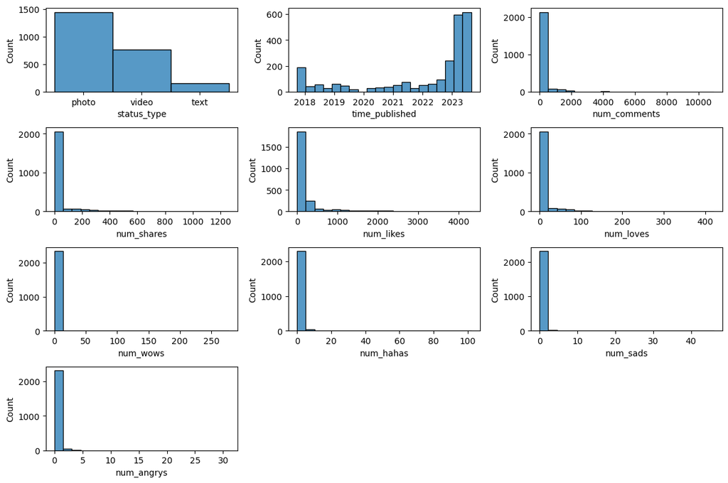

```python
# Generate histograms per feature.
# setting figure size
fig, ax = plt.subplots(figsize = (12, 8))
ax.remove()

# initializing a counter
count = 0

# looping to create visualizations
for col in df:

    if col == 'status_id':
        continue

    # increasing count
    count += 1

    # preparing histograms
    plt.subplot(4, 3, count)

    sns.histplot(x = df[col], log_scale=False, bins=20)


# formatting, saving, and displaying the plot
plt.tight_layout()
plt.show()
```

```python
# Extract just the numerical fields for analysis
df_numerical = df.drop(['status_id', 'status_type', 'time_published'], axis = 1)
```

```python
# Examine variance along each axis
np.var(df_numerical, axis=0)
```

```
num_comments    733040.526533
num_shares       15315.110634
num_likes       218288.813477
num_loves         1680.086166
num_wows            75.978259
num_hahas           16.896863
num_sads             3.392409
num_angrys           0.817271
dtype: float64
```

```python
# Scale numerical data in the dataframe using the scaler function
df_scaled = scaler(df = df_numerical)
```

```python
# Examine variance along each axis -- notice that they're all 1 now
np.var(df_scaled, axis=0)
```

```
num_comments    1.0
num_shares      1.0
num_likes       1.0
num_loves       1.0
num_wows        1.0
num_hahas       1.0
num_sads        1.0
num_angrys      1.0
dtype: float64
```

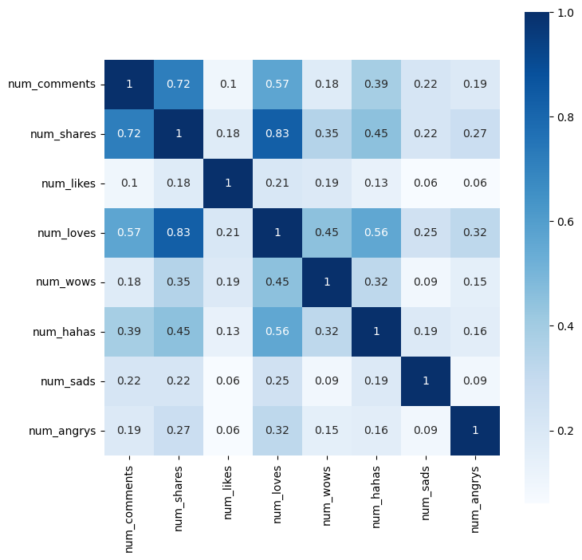

```python
# Examine the correlations to confirm candidates for PCA, and understand correlations at a high level.

# Setting plot size
fig, ax = plt.subplots(figsize = (8, 8))


# Developing a correlation matrix object
df_corr = df_scaled.corr(method = 'pearson').round(decimals = 2)


# Creating a correlation heatmap
sns.heatmap(data   = df_corr,
            cmap   = 'Blues',
            square = True,
            annot  = True)


# Rendering the heatmap
plt.show()
```

## PCA and Scree Plot

```python
# INSTANTIATING a PCA object with no limit to principal components
pca = PCA(n_components = None,
          random_state = 702)

# FITTING and TRANSFORMING the scaled data
data_pca = pca.fit_transform(df_scaled)

# Comparing dimensions of each DataFrame
print("Original shape:", df_scaled.shape)
print("PCA shape     :", data_pca.shape)
```

```
Original shape: (2362, 8)
PCA shape     : (2362, 8)
```

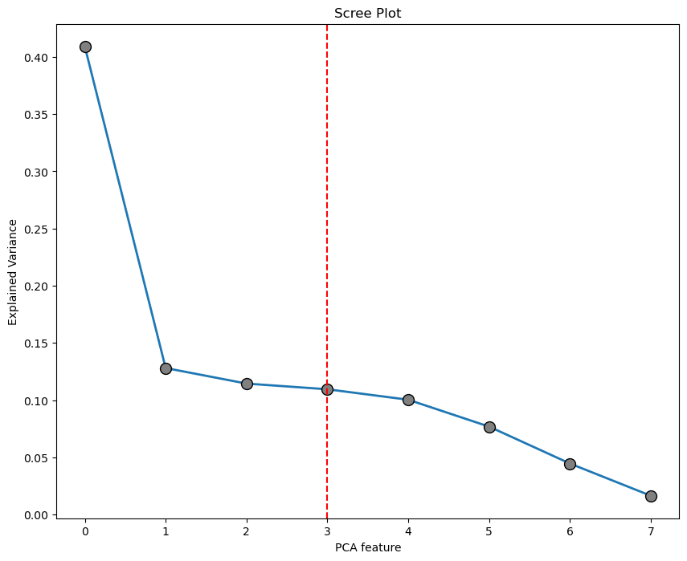

```python
# Generate a scree plot to visualize the variance explained by the top 4 principal components from PCA
scree_plot(pca, 3)
```

> Develop a scree plot and determine how many principal components you would like to retain. Draw a vertical line in the scree plot to indicate your cutoff point. Explain your rationale. (minimum 5 sentences)

Based on the Scree plot without any constraints on the number of features, I've determined that four principal components will be optimal for further analysis. This decision is based on two key considerations:

In conclusion, I selected four features based on these criteria: the presence of an elbow in the Scree plot and the components' combined contribution to a substantial portion of the dataset's variance, close to the 80% benchmark.

References: Ghiasian, S. E., & Lewis, K. (2020). A machine learning-based design recommender system for additive manufacturing. In Proceedings of the ASME 2020 International Design Engineering Technical Conferences & Computers and Information in Engineering Conference (IDETC/CIE 2020, Paper No. IDETC2020-22182, pp.7). St. Louis, Missouri, USA, August 16-19, 2020.

```python
# Instatiating a PCA object with 4 components
pca = PCA(n_components = 4,
          random_state = 24)

# Fitting and Transforming the scaled data
data_pca = pca.fit_transform(df_scaled)

# Comparing dimensions of each DataFrame
print("Original shape:", df_scaled.shape)
print("PCA shape     :", data_pca.shape)
```

```
Original shape: (2362, 8)
PCA shape     : (2362, 4)
```

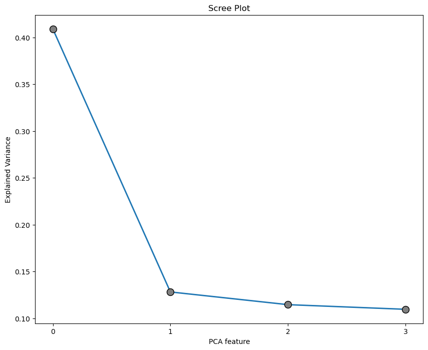

```python
# Check the scree plot to confirm what it looks like for just 4 components
scree_plot(pca)
```

```python
# First, we look at the explained variance to make sure that it explains at least 80% of the original dataset.
explained_variance = 0

# Initialize a counter to keep track of the number of components analyzed
component_number = 0

# Looping over each principal component's variance ratio to calculate the cumulative explained variance
for variance in pca.explained_variance_ratio_:
    component_number += 1
    explained_variance += variance.round(2)
    print(f"PC {component_number}: {variance.round(2)}")

# Print the total explained variance after the loop to assess how much of the data's total variance is captured by the components
print('Total explained_variance:', explained_variance)
```

```
PC 1: 0.41
PC 2: 0.13
PC 3: 0.11
PC 4: 0.11
Total explained_variance: 0.76
```

## Factor loadings for retained components

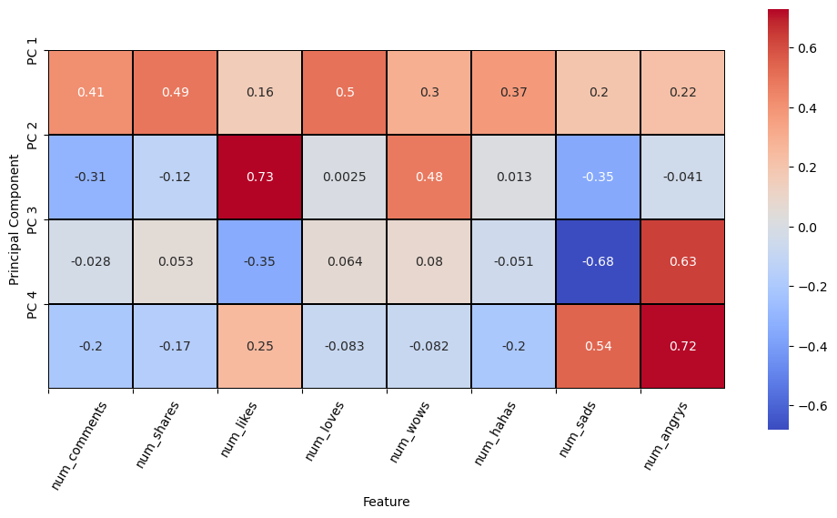

```python
# Visualize the correlation between original features and the principal components.

# Setting plot size
fig, ax = plt.subplots(figsize = (12, 6))

# Developing a heatmap to visualize the principal components' contributions to each feature
sns.heatmap(pca.components_,
            cmap = 'coolwarm',
            square = True,
            annot = True,
            fmt='.2g',
            linewidths = 0.1,
            linecolor = 'black')

# Setting y-axis labels with Principal Component identifiers
plt.yticks([0, 1, 2, 3],
           ["PC 1", "PC 2", "PC 3", "PC 4"])

# Setting x-axis labels with feature names from the scaled dataframe, adjusting the alignment and rotation for clarity
plt.xticks(range(0, 8),
           df_scaled.columns,
           rotation=60,
           ha='left')

# Adding labels to x and y axes
plt.xlabel(xlabel = "Feature")
plt.ylabel(ylabel = "Principal Component")

# Displaying the plot
plt.show()
```

```python
# Presenting the factor loadings for the retained principal components, rounded to two decimal places.
factor_loadings_df = pd.DataFrame(np.transpose(pca.components_.round(decimals = 2)))

# Naming rows as original features
factor_loadings_df = factor_loadings_df.set_index(df_scaled.columns)

# Checking the result
print(factor_loadings_df)
```

```
                 0     1     2     3
num_comments  0.41 -0.31 -0.03 -0.20
num_shares    0.49 -0.12  0.05 -0.17
num_likes     0.16  0.73 -0.35  0.25
num_loves     0.50  0.00  0.06 -0.08
num_wows      0.30  0.48  0.08 -0.08
num_hahas     0.37  0.01 -0.05 -0.20
num_sads      0.20 -0.35 -0.68  0.54
num_angrys    0.22 -0.04  0.63  0.72
```

> Interpret each of your retained principal components. Remember to interpret both sides of each principal component.

(minimum 5 sentences per principal component)

### 1. Principal Component 0 (PC0) - Highly Engaging

PC0 shows a profile in which all variables exhibit a positive correlation, although to varying degrees. This suggests that PC0 captures overall engagement of a post.

Specifically:

- Strongest Positive Correlation: 'num_loves' (0.50) holds the most substantial positive correlation with PC0, indicating that expressions of love are a pivotal element of this component. The 'Love' Reaction signifies a deep appreciation for the content, suggesting that the post has meaningfully connected with the audience. It can also denote strong support for a person or cause, showing that the post has touched the audience's heart in some significant way. This powerful correlation implies that PC0 might represent content that not only garners approval but also deeply resonates and evokes a heartfelt response from viewers, encompassing a full spectrum of positive emotional engagement.
- Strong Positive correlations: Other reactions such as 'num_shares' (0.49), 'num_comments' (0.41), 'num_hahas' (0.37), and 'num_wows' (0.30) also show strong positive correlations, suggesting that this component may represent a mix of content appreciation, humor, and surprise-aspects that actively engage users and encourage them to share their thoughts and spread the content.
- Weaker Correlations: 'num_likes' (0.16) demonstrate a positive but relatively modest influence on PC0, suggesting that 'likes' contribute to engagement but may not fully capture the emotional resonance of content in the way 'loves' do. On the other hand, "num_sads" (0.20) and "num_angrys" (0.22) also show positive correlations, albeit weaker, but carry significant weight in terms of emotional depth and complexity. The "sad" reaction can sometimes symbolize empathy and shared grief conveyed by the video; its positive correlation indicates that PC0 recognizes content that deeply moves the audience in a shared grief experience. Similarly, the reaction "angry" is used to denote disapproval and strong dissatisfaction, allowing users to express their discontent in a constructive way. Its correlation with PC0 emphasizes that engagement is not only about positive statements, but also about content that can critically engages and elicits strong responses.

These responses underscore that PC0 measures not only liking or loving the content, but also captures the range of emotions that the content elicits, including those of comfort, empathy, and shared dissent. In short, PC0 represents engaging content.

### 2. Principal Component 1 (PC1) - Positive and Surprising

PC1 is mostly represented by positive association with num_likes and num_wows and negative association from num_comments and num_sads. Overall, PC1 reprensents positive and surprising content.

- Strongest Positive Correlation: 'num_likes' (0.73) is strongly positively correlated with PC1.The traditional “Like” button on Facebook has been around since the platform’s inception. It was initially designed as a way for users to show their approval or agreement with a post or comment. However, over time, the meaning of the “Like” button has evolved.

“Like” button can signify various things depending on the context. It can indicate agreement, support, appreciation, or simply acknowledging that you have seen the post (BrandDad Social, 2023). It is a versatile tool that allows users to engage with content in a quick and straightforward manner. This suggests that PC1 may correspond to content that is broadly appealing and receives a high volume of positive acknowledgment from the audience.

- Strong Positive Correlation: 'num_wows' (0.48) also has a positive correlation, suggesting that PC1 reflects content that sometimes surprises or impresses the audience.
- No Correlation: 'num_loves' (0.00) and 'num_hahas' (0.01) show almost no correlation with PC1, which means that expressions of love and amusement do not significantly define this component. This could imply that the 'likes' and 'wows' are more indicative of content that is appreciated on a more casual or aesthetic level, rather than content that creates a strong emotional bond or comedic value.
- Negative Correlations: 'num_comments' (-0.31), 'num_sads' (-0.35), 'num_shares' (-0.12) and 'num_angrys' (-0.04) are negatively correlated with PC1. This suggests that content associated with this component tends to generate less discussion (fewer comments) and shares and is less likely to evoke feelings of sadness or anger. The negative correlation with comments could indicate that while the content is liked, it may not inspire extensive conversations or debates.

### 3. Principal Component 2 (PC2) - Outrageous

PC2 is most positively associated with num_angrys and negatively associated with num_likes and num_sads. It's worth noting that the dataset contains very few num_angry reactions (the 75% is 0 num_angry), so this field should be considered more of an outlier. However, still, because of the primary association with num_angrys and negative with num_likes and num_sad, PC2 overall represents outrageous content.

- Strongest Correlations, Positive and Negative: The most notable feature of PC2 is its strong positive correlation with 'num_angrys' (0.63) and a strong negative correlation with 'num_sads'(-0.68). This indicates that PC2 may represent posts that provoke a response of anger. It seems to capture the type of engagement where users are moved to express more confrontational or reactive emotions (anger) as opposed to more contemplative or empathetic emotions (sadness).
- Strong Negative Correlation : 'num_likes' (-0.35)
- Neutral to Weak Correlations: 'num_shares' (0.05), 'num_loves' (0.06), 'num_wows' (0.08), 'num_comments' (- 0.03),and 'num_hahas' (-0.05) show neutral to weak correlations with PC2.

### 4. Principal Component 3 (PC3) - Emotionally Polarizing

PC3 is most positively correlated with num_angrys and num_sads, and with some positive correlation with num_likes, which overall suggests it's emotionally polarizing content (diving reactions between positive and negative responses). This might represent content that deals with challenging or controversial topics that resonate deeply and personally with the audience, triggering these potent responses. The negative correlations with 'loves' and 'wows' may indicate that while the content is engaging, it may not be enjoyable in a conventional sense, but rather important, thought-provoking, or even upsetting

- Strongest Correlation: 'num_angrys' (0.72) shows the highest positive correlation, suggesting that PC3 may capture content that is most likely to provoke anger or frustration.
- Notable Positive Correlation: 'num_sads' (0.54) is also significantly correlated, indicating that this component represents content that can evoke feelings of sadness or empathy.
- Negative Correlations: 'num_loves' (-0.08) and 'num_wows' (-0.08) have slight negative correlations with PC3, suggesting that the content related to this component is less likely to inspire feelings of affection or surprise.
- Weaker Correlations: 'num_likes' (0.25) shows a moderate positive correlation, while 'num_comments' (-0.20), 'num_shares' (-0.17), and 'num_hahas' (-0.20) are negatively correlated. This pattern implies that PC3 is not predominantly about the amount of engagement (likes, comments, shares) or humor.

References: BrandDad Social. (2023, December 8). Decoding Facebook Reactions: Understanding the True Meanings of Like, Love, Care, Laugh, Wow, Sad, and Angry. Medium. https://medium.com

```python
# Renaming the columns of factor_loadings_df to reflect the nature of each principal component
factor_loadings_df.columns = [
    'Highly Engaging',
    'Positive and Surprising',
    'Outrageous',
    'Emotionally Polarizing',
]
```

```python
# Create a DataFrame from PCA results and set the column names using the factor loadings' labels for clarity
pca_df = pd.DataFrame(data_pca)
pca_df.columns = list(factor_loadings_df.columns)

# Display the first 5 rows of the DataFrame to inspect the PCA output
pca_df.head(n = 5)
```

|  | Highly Engaging | Positive and Surprising | Outrageous | Emotionally Polarizing |
| --- | --- | --- | --- | --- |
| 0 | -0.619670 | -0.006476 | 0.031211 | -0.028140 |
| 1 | -0.469623 | 0.126667 | 0.013848 | -0.028868 |
| 2 | -0.469004 | 0.125796 | 0.015559 | -0.028346 |
| 3 | 0.367677 | 0.240069 | -0.089732 | -0.314233 |
| 4 | -0.019679 | -0.278149 | -0.276109 | 0.109002 |

# Segmentation with k-means clustering

## k-means pre-processing

```python
# Observe how feature variance is not normalized after PCA
np.var(pca_df, axis=0)
```

```
Highly Engaging            3.273609
Positive and Surprising    1.025052
Outrageous                 0.916344
Emotionally Polarizing     0.876567
dtype: float64
```

```python
# Re-scale the data
pca_rescaled_df = scaler(df = pca_df)
```

```python
# Feature variance is normalized again.
np.var(pca_rescaled_df, axis=0)
```

```
Highly Engaging            1.0
Positive and Surprising    1.0
Outrageous                 1.0
Emotionally Polarizing     1.0
dtype: float64
```

## Choosing the right number of clusters

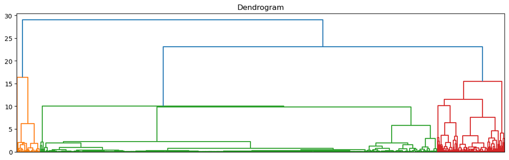

```python
# First, generate a dendrogram

# It takes a long time to generate a full dendrogram, so we take a random subset of 25% of the data
df_subset = pca_rescaled_df.sample(frac=0.25, random_state=702)

# Grouping data based on Ward distance
standard_mergings_ward = linkage(y = df_subset,
                                 method = 'ward',
                                 optimal_ordering = True)


# Setting plot size
fig, ax = plt.subplots(figsize=(14, 4))

# Developing a dendrogram
dendrogram(Z = standard_mergings_ward, no_labels=True)


# Rendering the plot
plt.title('Dendrogram')
plt.show()
```

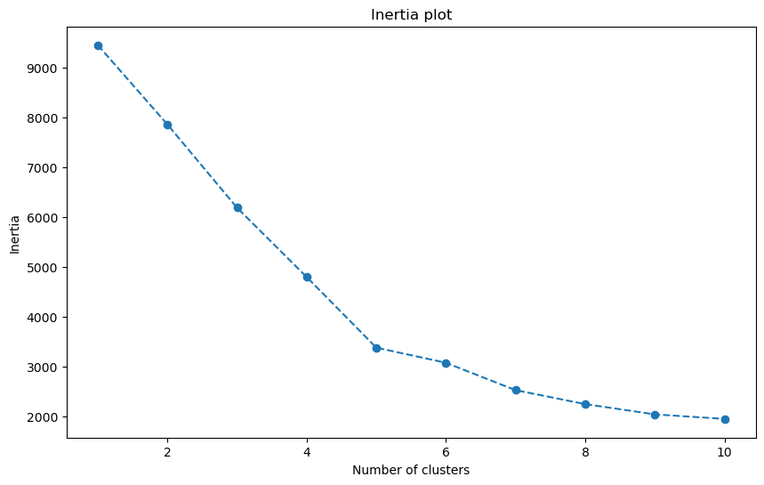

```python
# In order to help determine the ideal number of clusters, we look at the inertia per k
inertia = []

# Loop over a range of 1 to 10 clusters to perform k-means clustering and record the inertia for each k
for i in range(1, 11):
    kmeans = KMeans(n_clusters=i, random_state=702, n_init='auto')
    kmeans.fit(pca_rescaled_df)
    inertia.append(kmeans.inertia_)

# Plotting the inertia values to visually determine the optimal number of clusters using the 'elbow method'
plt.figure(figsize=(10, 6))
plt.plot(range(1, 11), inertia, marker='o', linestyle='--')
plt.title('Inertia plot')
plt.xlabel('Number of clusters')
plt.ylabel('Inertia')
plt.show()
```

## Why 5 clusters?

> Decide on an ideal number of clusters and explain your rationale. (minimum 5 sentences)

I chose 5 clusters for several main reasons:

1. The intertia plot has a clear elbow around k=5. Inertia represents roughly how well a KMeans model fits the data. As expected, k=1 does not fit the data that well (it's just one large group), and the inertia goes down with every increment in K. Also as expected, with a large number of K, the marginal benefit decreases, because if you have 9 clusters than having 10 will likely only fit the data slightly better. Observing the plot, it is clear that k=5 strikes an appropriate balance between having an efficient representation and sufficient inertia.
2. The dendrogram validates that there are roughly 4-6 main clusters (~two red, two green, one orange in the plot above). This further indicates that 5 is a reasonable choice.
3. Avoiding overfitting. I decided not to chose a larger number because it would risk overfitting the data, and prevent the KMeans model from being as helpful to generalize to new data.
4. Lastly, it’s important for me that each cluster has a meaningful interpretation and that the model performance is robust. The five-cluster solution appears to provide a solid balance between detail and generalizability, which is why I believe it’s the ideal number of clusters for my analysis.

```python
# INSTANTIATING a k-Means object with clusters
kmeans_pca = KMeans(n_clusters   = 5     ,
                    n_init       = 'auto',
                    random_state = 702   )

# Fitting the k-Means object to the PCA rescaled data
kmeans_pca.fit(pca_rescaled_df)


# Converting the cluster labels to a DataFrame for easier analysis
kmeans_pca_df = pd.DataFrame({'Cluster': kmeans_pca.labels_})


# Printing the count of data points in each cluster to check the distribution
print(kmeans_pca_df.iloc[: , 0].value_counts())
```

```
Cluster
0    2112
2     133
3     112
4       3
1       2
Name: count, dtype: int64
```

```python
# Storing cluster centers from the fitted k-Means model
centroids_pca = kmeans_pca.cluster_centers_

# Converting the cluster centers into a DataFrame and rounding off to two decimal places for clarity
centroids_pca_df = pd.DataFrame(centroids_pca).round(decimals = 2)

# Renaming the columns of the DataFrame to match the principal components' names for better interpretability
centroids_pca_df.columns = pca_df.columns

# Displaying the DataFrame to check results with clusters as rows and principal components as columns
centroids_pca_df
```

|  | Highly Engaging | Positive and Surprising | Outrageous | Emotionally Polarizing |
| --- | --- | --- | --- | --- |
| 0 | -0.21 | -0.12 | 0.07 | -0.05 |
| 1 | 3.26 | -0.99 | 18.06 | 21.39 |
| 2 | 0.40 | 2.96 | -1.10 | 0.79 |
| 3 | 3.31 | -1.03 | 0.14 | -0.68 |
| 4 | 4.68 | -7.00 | -15.87 | 13.33 |

### Presenting each segment with cluster centroids

```python
# Concatenating cluster assignments, PCA-transformed data, and the original 'status_type' column into a single DataFrame for comprehensive analysis
final_df = pd.concat([kmeans_pca_df, pca_df, df['status_type']], axis=1)
```

```python
# Displaying the first 5 rows of the final DataFrame to inspect the merged data structure
final_df.head()
```

|  | Cluster | Highly Engaging | Positive and Surprising | Outrageous | Emotionally Polarizing | status_type |
| --- | --- | --- | --- | --- | --- | --- |
| 0 | 0 | -0.619670 | -0.006476 | 0.031211 | -0.028140 | photo |
| 1 | 0 | -0.469623 | 0.126667 | 0.013848 | -0.028868 | photo |
| 2 | 0 | -0.469004 | 0.125796 | 0.015559 | -0.028346 | photo |
| 3 | 0 | 0.367677 | 0.240069 | -0.089732 | -0.314233 | video |
| 4 | 0 | -0.019679 | -0.278149 | -0.276109 | 0.109002 | video |

```python
# Mapping cluster numbers to example post IDs for reference
cluster_to_example_id = {
    0: 2019,
    1: 1117,
    2: 379,
    3: 1524,
    4: 2072
}

# Loop through each cluster and print a dynamic string with information about that cluster
for cluster_i in range(5):
    print(f"""\
 -----------
| Cluster {cluster_i + 1} |
 -----------
Percent of Observations: {
    round(len(final_df.loc[ : , "Cluster"][final_df.loc[ : , "Cluster"] == cluster_i]) /
    len(final_df), ndigits = 4) * 100}%

Centroid:
----------
{centroids_pca_df.loc[cluster_i , :].to_string(dtype = False, name = False)}

Example 'normal' post
------------""")
    example_id = cluster_to_example_id[cluster_i]

# Printing details of an example post from each cluster using its specific 'status_id'
    print(df.loc[df['status_id'] == example_id].iloc[0])
```

```
 -----------
| Cluster 1 |
 -----------
Percent of Observations: 89.42%

Centroid:
----------
Highly Engaging           -0.21
Positive and Surprising   -0.12
Outrageous                 0.07
Emotionally Polarizing    -0.05

Example 'normal' post
------------
status_id                        2019
status_type                     photo
time_published    2023-02-02 02:31:00
num_comments                        3
num_shares                          0
num_likes                          10
num_loves                           0
num_wows                            0
num_hahas                           0
num_sads                            0
num_angrys                          0
Name: 2018, dtype: object
 -----------
| Cluster 2 |
 -----------
Percent of Observations: 0.08%

Centroid:
----------
Highly Engaging             3.26
Positive and Surprising    -0.99
Outrageous                 18.06
Emotionally Polarizing     21.39

Example 'normal' post
------------
```

[output cut: 75 more lines]

```

Example 'normal' post
------------
status_id                        2072
status_type                     photo
time_published    2023-08-17 06:57:00
num_comments                       42
num_shares                          2
num_likes                         285
num_loves                           5
num_wows                            0
num_hahas                           0
num_sads                           46
num_angrys                          0
Name: 2071, dtype: object
```

## Interpretenting segments and "normal" posts

> Present and interpret each segment using cluster centroids and give an example of a "normal" post for each segment. (minimum 5 sentences per segment)

### Cluster 1 - Not Engaging 🥱

Cluster 1's centroid has negative values for all of the principal components, except for a very slight positive value for outrageous. However, as mentioned prior, the Outrageous component is less sensitive and more targeted at outliers because num_angrys is almost always 0 in the data.

This cluster represents a majority (89%) of the dataset, which is understandable and unsurprising because only a small fraction of the content posted on the internet is engaging to others and gets surfaced to the top via recommendations.

A fictious such post could be: "Just uploaded new product photos. Check them out if you want."

### Cluster 2 - Angry Outliers 😡

First, it is important to note that this segment is very rare, comprising only 0.08% of observations (just 2 data points). Thus, it is an outlier within the broader content spectrum.

That said, these posts are characterized by very large positive values for Outrageous and Emotionally Polarizing components, as well as a small positive value for highly engaging and a slightly negative value for positive and surprising. Because of the negative value on the positive component, and the very large values for outrageous and polarizing which are most correlated with num_angrys, I name this small group of 2 posts to be the Angry Outliers.

An example of a "normal" post is represented by "status_id 1117", which has 31 angry reactions, 44 comments, and a handful of other reactions -- clearly an example of an angry outlier.

A fictious example post could be: "Big sale on our most popular items, but only for customers in Hanoi! Sorry, if you’re outside the city, you're missing out on these deals. Seems fair, right? #ExclusiveSale 😡 [Picture of items]"

### Cluster 3 - Positive and Surprising 🤩

Cluster 3 represents 5.6% of the dataset, making it one of the next largest clusters after cluster 1. This cluster is characterized by positive and surprising content (2.96), being very not outrageous (-1.1), pretty polarizing (0.8), and positively engaging (0.4).

Cluster 3's content is typically engaging, drawing likes, shares, and comments. While the content does have a postive value for being emotionally polarizing, the negative correlation with the 'outrageous' suggests a level of balance, and decreases the likelihood of angry reactions. This implies that while the content prompts engagement and potentially strong reactions, it doesn't typically lead to extreme controversy or outlandish responses.

An example of "normal" content is represented by "status_id 379", which got 1140 likes, 297 comments, and 92 shares, and no other reactions. It's very engaging, shareable content, and seems like the type that could be surprising (which elicits all the shares).

A real example post could be "Exciting news! For the first time ever, we’re launching a nationwide shipping service so everyone in Vietnam can enjoy our products at the same great prices as Hanoi. Plus, the first 100 orders get an exclusive 10% discount! Share this with friends and family who’ve been waiting to try our products! 🎉 #NationwideLaunch"

### Cluster 4 - Super Engaging 😁

Cluster 4 represents 4.7% of the dataset, and is the 3rd of the main clusters (1, 3, and 4). It is characterized by being highly engaging (3.31), not that "positive and surprising" (-1.03), slightly outrageous (0.14), and not polarizing (-0.68).

This cluster is primarily characterized by its highly engaging nature, boasting a significant volume of comments and shares. The negative correlation with "emotionally polarizing" suggests that the content tends to evoke reactions of love, laughter and amazement more than anger and sadness, which are less represented.

An example of a "normal" post is "status_id 1524", a video that got 2k comments, 750 shares, 834 likes, 336 loves, 35 wows, and a couple of laugh/sad/angry reactions. Overall, it's extremely engaging.

And here is a potential real world example: "🌟 We’re celebrating our 5th anniversary with a bang! To show our gratitude, we’ve created a limited edition product line that tells the story of our journey. Plus, we’re giving away gifts with every purchase made this week. Let’s make some happy memories together! Share this joyous moment with your friends and family. 🎉🎁 #AnniversaryCelebration"

### Cluster 5 - Sad Outliers 😭

Cluster 5 is another outlier group, representing only 0.13% of the data (3 points), making it the second of two outliers of the 5 groups.

These 3 outlier posts are characterized by a very negative outrageous value (-15.87), a very large polarizing value (13.33), a very low positive/surprising value (-7) and being rather engaging (4.7) which together suggest rather than having any angry reactions, the posts simply garner lots of sad reactions, and some comments and shares.

A good example is "status_id 2072", a photo that got 46 sad reactions, 285 likes and 42 comments, as well as a couple of other shares and a small number of loves, but no angry, haha, or wow reacts.

Overall, this small group represents sad outliers.

Here's an example such post: "As we prepare for a new chapter, we can't help but look back with a mix of emotions. This photo shows where it all started—our humble stall at the local market. Rising costs are forcing us to move, and though we're sad to leave this special place, we're also hopeful about what lies ahead. Thank you for being part of our story. Here's to growing and creating new memories together! 🌟💔 #NewBeginnings"

## Renaming segments

> Rename each segment based on your interpretation of what it represents.

```python
# Rename each segment by assigning descriptive names to clusters for better interpretability of analysis results
cluster_names = {
    0: 'Not Engaging',
    1: 'Angry Outliers',
    2: 'Positive and Surprising',
    3: 'Super Engaging',
    4: 'Sad Outliers'
}

# Replace numeric cluster IDs with descriptive names in the final DataFrame
final_df['Cluster'].replace(cluster_names, inplace = True)
```

## Analyzing status types of each segment

```python
# Count the number of occurrences for each combination of 'Cluster' and 'status_type' categories, specifically looking at the 'Highly Engaging' column
final_df.groupby(['Cluster', 'status_type', ]).count()['Highly Engaging']
```

```
Cluster                  status_type
Angry Outliers           photo             2
Not Engaging             photo          1365
                         text            127
                         video           620
Positive and Surprising  photo            71
                         text             29
                         video            33
Sad Outliers             photo             2
                         video             1
Super Engaging           photo             3
                         video           109
Name: Highly Engaging, dtype: int64
```

> Analyze the status types of each segment and report any findings related to photos. (minimum 5 sentences)

Above are the status types of each segment. As previously mentioned, the outlier groups are indeed very small. Angry Outliers has only 2 posts (both are photos), and the Sad Outliers has just 3 (2 photos and 1 video). It's worth immediately pointing out that the outliers are mostly photos -- indicating that photos do have the potential more than other mediums to produce outlier content that makes viewers angry or sad (more than video or text).

The "super engaging" cluster is mostly videos (only a couple of photos), and the "positive and surprising" cluster contains a mix of all content.

Overall, the breakdown illustrates that photos can be engaging, though not quite as engaging as videos, and have the potential for more outlier posts that can elicit more anger or sad reactions.

# Developing three logistic regression models

```python
# Classification setting: 1 = photo, 0 = not photo
y_data = (df['status_type'] == 'photo').astype(int)
```

```python
# Splitting the data into training and testing sets with 25% of data as test set,
    # ensuring the same proportion of classes in both sets using stratification
def train_and_eval_model(x_data):
    x_train, x_test, y_train, y_test = train_test_split(x_data,
                                                        y_data,
                                                        test_size    = 0.25,
                                                        random_state = 702,
                                                        stratify     = y_data)

    # Instantiating a logistic regression model with a specified solver and random state for reproducibility
    model = sklearn.linear_model.LogisticRegression(
        solver = 'lbfgs',
        random_state = 702
    )

    # Fitting the model on the training data
    model_fit = model.fit(x_train, y_train)

    # Predicting the target variable for the test dataset
    model_pred = model_fit.predict(x_test) # predict_proba for multiclass

    # Evaluating the model by comparing actual and predicted values
    train_acc = model_fit.score(x_train, y_train)
    test_acc  = model_fit.score(x_test , y_test )
    roc_score = roc_auc_score  (y_true      = y_test,
                                y_score     = model_pred)

    # Printing performance metrics
    print(f'train acc {train_acc:0.3f}', )
    print(f'test acc {test_acc:0.3f}', )
    print(f"""
Train-Test Gap: {round(abs(train_acc - test_acc), ndigits = 3)}
Test AUC Score: {roc_score.round(decimals = 3)}
    """)
    model_tn, \
    model_fp, \
    model_fn, \
    model_tp = confusion_matrix(y_true = y_test, y_pred = model_pred).ravel()

    # Unpacking and printing confusion matrix components to understand classification errors
    print(f"""
True Negatives : {model_tn}
False Positives: {model_fp}
False Negatives: {model_fn}
True Positives : {model_tp}
    """)
```

```python
# Model 1: Original x-features
x_data = df.drop(['status_id', 'status_type', 'time_published'], axis = 1)
train_and_eval_model(x_data)
```

```
train acc 0.756
test acc 0.739

Train-Test Gap: 0.017
Test AUC Score: 0.678


True Negatives : 92
False Positives: 138
False Negatives: 16
True Positives : 345
```

```python
# Model 2: Retained principal components
x_data = pca_rescaled_df.copy()
train_and_eval_model(x_data)
```

```
train acc 0.742
test acc 0.736

Train-Test Gap: 0.006
Test AUC Score: 0.67


True Negatives : 86
False Positives: 144
False Negatives: 12
True Positives : 349
```

```python
# Model 3: Retained clusters (with the pca data)
x_data = pd.concat([kmeans_pca_df, pca_df], axis=1)
train_and_eval_model(x_data)
```

```
train acc 0.744
test acc 0.734

Train-Test Gap: 0.009
Test AUC Score: 0.669


True Negatives : 86
False Positives: 144
False Negatives: 13
True Positives : 348
```

# Model analysis

> Your rationale for why this is the best model. (minimum 5 sentences)

The best model of the above is Model 2 (Retained principal components) -- which uses the retained principal components. As shown, this model has a test AUC (0.67) that is almost the same as the original features model (0.678), so it is comparable in terms of performance. However, the main advantage of Model 2 is that the train-test gap is the smallest of all the models, at 0.006 (compared to 0.009 for Model 3 and 0.017 for Model 1). This suggests that Model 2 has the greatest ability to generalize to new data out of all three of the models, and is less likely to overfit the training data.

Compared to Model 3, Model 2 is definitely the better choice because it has both a better test AUC score and a lower train-test gap. Further, being a simpler model (not requiring the KMeans cluster feature), it is simpler to compute, which is another advantage.

In short, I've chosen Model 2 as the best because it has test performance that is on par with the top score, and has the lowest train-test gap of all the models.

## Model results

> train-test gap based on accuracy and AUC score based on the results of the .predict step

As copied from above:

```
Train-Test Gap: 0.006 (train = 0.742, test = 0.736)
Test AUC Score: 0.67
```

## Confusion Matrix

> Confusion matrix: Explain each error and its associated risks for the business. (minimum 5 sentences)

```
True Negatives : 86
False Positives: 144
False Negatives: 12
True Positives : 349
```

True Positive and True Negatives represent examples that the model predicted correctly, and thus are not errors and do not pose a risk to the business.

However, the 144 False Positives and 12 False Negatives are all errors, and do represent risks for the business. Generally speaking, a False Positive represents when the model incorrectly makes a positive prediction (when the true value is negative) and the risk would be when a negative example being considered as a positive (e.g. in a spam filter, a valid email may be incorrectly flagged as spam, which is why sometimes people as you to check your spam folder).

Conversely, a False Negative represents when the model incorrectly makes a negative prediction (when the true value is positive), and the risk would be considering a positive value as a negative. In the case of the spam filter, this could mean a spam email gets through to your inbox (which happens sometimes).

As a reminder of the stated machine learning problem here, the input is a list of features about a post and the output is whether said post is a photo post, or a video/text post. This may not necessarily seem like an important problem to solve on first glance, but the premise is that a Vietnamese marketing firm is looking to gain insights about posts and this prediction task can provide important insights for the business and the advice it shares with clients about how to make the most engaging posts.

The company has long operated under the idea that photos are the most engaging forms of content, and that they should advice their clients to post as many of them as they can -- I have already invalidated this hypothesis partly from the initial analysis at the start of the report.

However, now that I've built an ML model that can predict whether a post is a photo or non-photo post, this could potentially be helpful to glean insights into what constitutes a photo post.